# Comparison of Two Linear Regression Models for O2 Saturation of Seawater

Samantha Kuglen

January 22nd, 2022

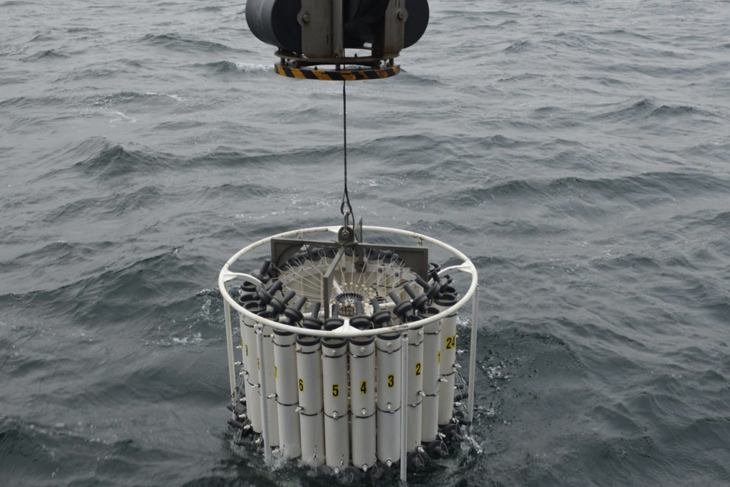

### A. Overview

This report provides an exploratory review on the relationship between O2 saturation of seawater off California’s coast and several physical and chemical variables. Specifically, we examine and compare model selection for :

1. Oxygen saturation as a function of water temperature, salinity, and phosphate concentration
2. Oxygen saturation as a function of water temp, salinity, phosphate concentration, and depth

The purpose of this analysis is to determine which of the two models is more parsimonious, or in other words, provides predictive performance with simplicity and accuracy.

This data is important because it provides important information about seawater in the California Current System that may influence or affect ecosystem processes.

### B. Data and Analysis

The data contain observations from [CalCOFI seawater sample data](https://calcofi.org/ccdata.html). A 70+ year hydrographic time-series includes temperature, salinity, oxygen and phosphate observations, along with nutrient analysis of silicate, nitrate and nitrite. An AIC corrected (AICc) comparison between the two models is used to inform which model is a better fit, with preference for the model with lower AICc. Following AICc comparison of two linear regression models, a ten-fold cross validation is performed.

The cross validation reserves a subset of data (test data) and trains our model using the rest (training data) to estimate the model parameters. All analyses are in R version 4.0.2 using RStudio version 1.3.1056.

```r
knitr::opts_chunk$set(echo = TRUE, message = FALSE, warning = FALSE)

# Attach packages
library(tidyverse)
library(here)
library(AICcmodavg)
library(kableExtra)
library(huxtable)
library(gt)
```

```r
# Read in the data
calcofi_data <- read_csv(here("data", "calcofi_seawater_samples.csv"))
```

#### I. AIC Comparison of Two Linear Regression Models

**Model 1:** Oxygen saturation as a function of water temperature, salinity, and phosphate concentration. **Model 2:** Oxygen saturation as a function of water temp, salinity, phosphate concentration, and depth.

```r
# Model 1 linear model with defined parameters
f1 <- o2sat ~ t_deg_c + salinity + po4u_m
mdl1 <- lm(f1, data = calcofi_data)

# Model 2 linear model with defined parameters
f2 <- o2sat ~ t_deg_c + salinity + po4u_m + depth_m
mdl2 <- lm(f2, data = calcofi_data)
```

AICc is used to select the better model, with a consideration the difference of AICc between the two models.

```r
# Use `aictab` to compare the models
aic_table <- AICcmodavg::aictab(list(mdl1, mdl2)) %>%
  rename("Model" = "Modnames")

kable(aic_table,
      caption = "Table 1: Models 1 and 2 AIC corrected (AICc) Values") %>%
  kable_styling(bootstrap_options = "striped",
                full_width = FALSE)
```

Table 1: Models 1 and 2 AIC corrected (AICc) Values

|  | Model | K | AICc | Delta_AICc | ModelLik | AICcWt | LL | Cum.Wt |
| --- | --- | --- | --- | --- | --- | --- | --- | --- |
| 2 | Mod2 | 6 | 616.6048 | 0.000000 | 1.0000000 | 0.7703216 | -301.8508 | 0.7703216 |
| 1 | Mod1 | 5 | 619.0251 | 2.420256 | 0.2981592 | 0.2296784 | -304.1934 | 1.0000000 |

Model 2’s AICc is 616.605 while Model 1’s AICc 619.025, with a difference in AIC’s of 2.42. Model 2’s AICc is lower than model 1 and means that it is the preferred model and a better fit, based on AICc.

#### II. Ten-fold Cross Validation of the Two Models

Ten-fold cross validation is used with root-mean-square error (RMSE) as the scoring method and the final model is trained on the full dataset.

```r
# Assign number of folds and create a folds vector
folds <- 10
fold_vec <- rep(1:folds, length.out = nrow(calcofi_data))

# Starting number to generate sequence of random numbers
set.seed(50)

seawater_fold <- calcofi_data %>%
  mutate(group = sample(fold_vec, size = n(), replace = FALSE))

# First fold
test_df <- seawater_fold %>%
  filter(group == 1)
train_df <- seawater_fold %>%
  filter(group != 1)
```

RMSE goes in reverse order of these operations - find error (predicted actual), square it, find the average, then take the square root.

```r
# Calculate the RMSE value
calc_rmse <- function(x, y) {
  rmse_result <- (x - y)^2 %>%  mean() %>%  sqrt()
  return(rmse_result)
}
```

The training dataset is used to create two linear regression models, based on the formulas above.

```r
# Training dataset is based on fold 1
training_mdl1 <- lm(f1, data = train_df)
training_mdl2 <- lm(f2, data = train_df)
```

The trained models are then used to predict on test data.

```r
predict_test <- test_df %>%
  mutate(model1 = predict(training_mdl1, test_df),
         model2 = predict(training_mdl2, test_df))

# Calculate RMSE values
rmse_predict_test <- predict_test %>%
  summarize(rmse_mdl1 = round(calc_rmse(model1, o2sat), digits = 3),
            rmse_mdl2 = round(calc_rmse(model2, o2sat), digits = 3))

kable(rmse_predict_test,
      col = c("RMSE Model 1",
              "RMSE Model 2"),
      caption = "Table 2: Test Data RMSE Values for Models 1 and 2") %>%
  kable_styling(bootstrap_options = "striped",
                full_width = FALSE)
```

Table 2: Test Data RMSE Values for Models 1 and 2

| RMSE Model 1 | RMSE Model 2 |
| --- | --- |
| 5.895 | 5.501 |

Comparison of RMSE values for Models 1 and 2 using the test dataframe with fold 1. RMSE for model 2 is lower, so it is preferred.

Calculation over all folds and taking the average of RMSE values.

```r
rmse_df <- data.frame()

# Iterate over all 10 folds to get RMSE values and store in a dataframe
for(i in 1:folds) {
  kfold_test_df <- seawater_fold %>%
    filter(group == i)
  kfold_train_df <- seawater_fold %>%
    filter(group != i)

  kfold_mdl1 <- lm(f1, data = kfold_train_df)
  kfold_mdl2 <- lm(f2, data = kfold_train_df)

  kfold_pred_df <- kfold_test_df %>%
    mutate(mdl1 = predict(kfold_mdl1, kfold_test_df),
           mdl2 = predict(kfold_mdl2, .))

  kfold_rmse <- kfold_pred_df %>%
    summarize(rmse_mdl1 = calc_rmse(mdl1, o2sat),
              rmse_mdl2 = calc_rmse(mdl2, o2sat))

  rmse_df <- bind_rows(rmse_df, kfold_rmse)
}

# Use the dataframe from above to calculate the mean RMSE values for each model
rmse_table <- rmse_df %>%
  summarize(mean_rmse_mdl1 = mean(rmse_mdl1),
            mean_rmse_mdl2 = mean(rmse_mdl2))

kable(rmse_table,
      col = c("Mean RMSE Model 1",
                      "Mean RMSE Model 2"),
      caption = "Table 3: Average RMSE values for each model over all folds") %>%
  kable_styling(bootstrap_options = "striped",
                full_width = FALSE)
```

Table 3: Average RMSE values for each model over all folds

| Mean RMSE Model 1 | Mean RMSE Model 2 |
| --- | --- |
| 4.826589 | 4.709636 |

We find that Model 2 has a lower average RMSE than Model 1, at values of 4.71 and 4.827, respectively. The 10 cross validation informs us that Model 2 has the best fit and predicts the observed values for oxygen saturation `o2sat` with the most accuracy.

Once we have chosen the model via cross validation (Model 2), we train our final model on our entire dataset.

```r
final_mdl <- lm(f2, data = calcofi_data)
```

Our final parameterized model with coefficients:

```r
kable(summary(final_mdl)$coefficients, format = "html",
      caption = "Coefficients of the Final Model. Significance codes: 0 '***' 0.001 '**' 0.01 '*' 0.05 '.' 0.1 ' ' 1",
      col.names = c("Estimate", "Std. Error", "t value", "Pr(>|t|)")) %>%
  kable_styling(bootstrap_options = c("striped", "hover", "condensed"),
                full_width = F) %>%
  column_spec(1, bold = TRUE, color = "blue") %>%
  row_spec(0, bold = TRUE, background = "#f5f5dc")
```

Coefficients of the Final Model. Significance codes: 0 ‘**’ 0.001 ’**’ 0.01 ’’ 0.05 ‘.’ 0.1 ’ ’ 1

|  | Estimate | Std. Error | t value | Pr(>\|t\|) |
| --- | --- | --- | --- | --- |
| (Intercept) | 144.0668619 | 95.3673021 | 1.5106526 | 0.1341962 |
| t_deg_c | -0.7498091 | 0.4049372 | -1.8516675 | 0.0671797 |
| salinity | -0.4394458 | 2.9889717 | -0.1470224 | 0.8834259 |
| po4u_m | -37.7115914 | 2.5011266 | -15.0778419 | 0.0000000 |
| depth_m | -0.0319570 | 0.0149704 | -2.1346754 | 0.0353611 |

### Summary

Data analysis reveals the following findings:

- Model 2’s AICc is lower than Model 1 and means that it is the preferred model and a better fit, based on AICc.
- Model 2 has a lower average RMSE than Model 1. The 10-fold cross validation informs us that Model 2 has the best fit and predicts the observed values for oxygen saturation `o2sat` with the most accuracy.
- Model 2: *Oxygen saturation as a function of water temp, salinity, phosphate concentration, and depth* is overall the most accurate model to inform our final parameterized model.

### Data Citation

CalCOFI data are available for use without restriction. Data downloaded from https://calcofi.org/ccdata.html. Accessed 1/10/2022.